# The Effect Inflation Dataset

Source Audit, Coding Rules, and Construction Workflow

Author

Rex W. Douglass PhD

Published

April 24, 2026

Rex W. Douglass PhD — rexdouglass.com — April 24, 2026

Technical companion / source audit / construction dossier

# Abstract

This companion paper documents the construction of the **Effect Inflation Dataset**, the source-audited corpus used to study how published small-$N$ effect sizes compare with later larger-sample follow-ups. The goal of the dataset is narrower than the goal of the main paper. The main paper argues that most published small-$N$ claims are inflated. This paper explains exactly **which sources were searched, which were included, which were blocked, how rows were coded, and why particular design choices were made**.

The dataset currently has two distinct layers. The first is a **live integrated pair corpus** used for the cross-source `D`-based analyses in the main manuscript. The second is a broader **staging and audit layer** that records sources that were real but not yet promotable under the current shared-metric rules. Keeping these layers separate is deliberate. It prevents weak or poorly matched sources from contaminating the live corpus while preserving a detailed audit trail of what was tried and what remains recoverable.

# 1 Purpose

This dataset paper is now organized around the **plot program** rather than around a generic workflow taxonomy.

The logic is simple:

- **Plot 1** is the replication-pairs plot,
- **Plot 2** is the published-paper endpoint plot,
- **Plot 3** is the preregistered-results plot,
- **Plot 4** is the first-pass all-source `D`/`N` dump.

Each figure section now follows the same plot-first audit structure:

1. the figure,
2. inclusion criteria,
3. corpora considered, with citation, description, in/out rationale, and observation count,
4. specific observations included, with row-level paper/result details where the project has them.

## 1.1 Plot Catalog Status

Machine-readable summary: plot_catalog_status.csv

Cross-plot ownership ledgers:

- plot_dot_membership.tsv records every rendered D/N result dot across Plots 1-4, with its own result-level citation key and rendered citation string in plot_dot_references.bib, plus the parent source citation key/rendered citation in `docs/references.bib`.
- plot_result_parent_child.tsv records the parent collection / corpus / plot source to child result-dot mapping, allowing the same child result or paper to appear in more than one parent collection.
- plot_paper_summary.tsv collapses child result dots to normalized paper/unit keys and reports result counts plus D/N min, median, and max.
- plot_paper_membership.tsv records the paper/unit-level owner for Plots 1-3, including source, citation key, `@key` citation ref, BibTeX presence in `docs/references.bib`, row unit, D/N median, rows represented, and the collapse or selection rule.
- plot_paper_exclusivity_audit.tsv groups the membership ledger by normalized paper/unit key and flags any cross-plot overlaps or weak fallback keys for review; citation keys are carried through for each grouped unit.
- plot_source_family_membership.tsv records which source families/corpora were considered by which plot catalogs, with BibTeX mapping status.
- plot_assignment_rules.tsv states the current mutually exclusive plot-assignment rules.

| Plot | Catalog maturity | Included | Support-only | Considered out | Main missing piece |
| --- | --- | --- | --- | --- | --- |
| Plot 1 — Replication Pairs | mature audit | 57 | 1 | 29 | Resolve the remaining raw/staged lead families by parser, metric-conversion, access, or native-metric-lane decision. |
| Plot 2 — Published Paper Endpoints | source audit built | 26 | 0 | 9 | Add source-specific collapse-rule prose and resolve high-yield excluded candidates by parser, access, or policy decision. |
| Plot 3 — Preregistered Results | first figure / partial audit | 47 | 0 | 31 | Expand the considered-source sweep and add a formal preregistered-source evidence inventory. |
| Plot 4 — All-Source D/N Dump | first-pass surface map | 4 | 1 | 1 | Formalize deduplication rules and a native-metric sidecar policy before using this layer inferentially. |

## 1.2 Provenance Schema And 300-Row Retrace Pilot

The dataset is moving toward a source-result provenance model. The lowest-level row should be a result asserted by a specific extraction source, not merely a plotted dot. That row must preserve original text, parsed native values, standardized `D`/`N`, source access details, and the transformation explanation.

The current target tables are:

- `source.tsv`: citeable or computational source objects such as papers, registries, corpora, repositories, databases, PDFs, and reports.
- `source_access.tsv`: exact retrieval route and local mirror, including direct URL/API URL, repo-relative local path, content type, file size, checksum, retrieval method, and access barrier.
- `source_result.tsv`: one extraction-source assertion of one result, including verbatim effect/N/p/CI/outcome text, parsed native values, standardized values, and transformation notes.
- `canonical_result.tsv`: deduplicated result selected or summarized from one or more source-result rows.
- `source_source_mapping.tsv`: relationships such as corpus contains paper, database reports paper, package supports paper, or registry preregisters trial.
- `extraction_event.tsv`: download, user upload, unzip, PDF/table extraction, code execution, failure, and other work needed to obtain the bytes.

Synthetic `dot_plot_...` citations are internal audit records for rendered dots. They are kept as `generated_result_citation_*` fields and should not be treated as bibliographic citations for the represented paper, trial, registry record, or dataset.

The 300-row pilot is a reproducibility stress test: start from sampled plotted rows, retrace them through the plot files, then try to recover the upstream local source rows and literal numeric inputs. Inspect the human-check table first; the initial source-result table is a structural mapping and intentionally keeps labels separate from unrecovered verbatim text.

Machine-readable pilot files:

- Formal table codebook: provenance_codebook.tsv
- Field data dictionary: provenance_data_dictionary.tsv
- Empty TSV templates: schema_templates/
- Human-check extraction rows: human_check_source_result_sample_300.tsv
- Initial source-result coding: source_result_sample_300.tsv
- Source objects: source_sample_300.tsv
- Access objects: source_access_sample_300.tsv
- Canonical results: canonical_result_sample_300.tsv
- Source mappings: source_source_mapping_sample_300.tsv
- Retraced source-result rows: retrace_source_result_sample_300.tsv
- Retrace events: retrace_events_sample_300.tsv
- Retrace problems: retrace_problems_sample_300.tsv
- Initial coding summary: coding_summary_sample_300.tsv
- Retrace summary: retrace_summary_sample_300.tsv

[output not shown]

The pilot result is mixed in exactly the useful way: the plotted rows are reproducible, but the current pipeline still often reaches a derived numeric row rather than the original human-readable table/API text. Future extractors should write source-result rows at extraction time so the verbatim cells are preserved before collapsing, cleaning, or converting to `D`.

## 1.3 Source Citation Coverage

Machine-readable gap log: source_citation_gaps.csv

Any source row that renders without an inline citation is now tracked explicitly here. This turns missing citations into a concrete cataloging queue rather than a visual annoyance caught in screenshots.

Current uncited source rows: `0` across Plot 1-3 source catalogs.

### 1.3.1 Uncited-row counts by plot and priority

| Plot | Priority | Uncited rows |
| --- | --- | --- |

### 1.3.2 Highest-priority uncited rows

| Plot | Source row | Inclusion status | Priority | Gap reason |
| --- | --- | --- | --- | --- |

High-priority rows are included source families whose visible labels look like project titles rather than file artifacts. Those are the best low-hanging fruit for tightening citation coverage without changing plot logic.

# 2 Plot 1 — Replication Pairs

This is the most mature plot in the project. It is the cross-source original-versus-larger-follow-up figure used in the main manuscript.

## 2.1 Figure

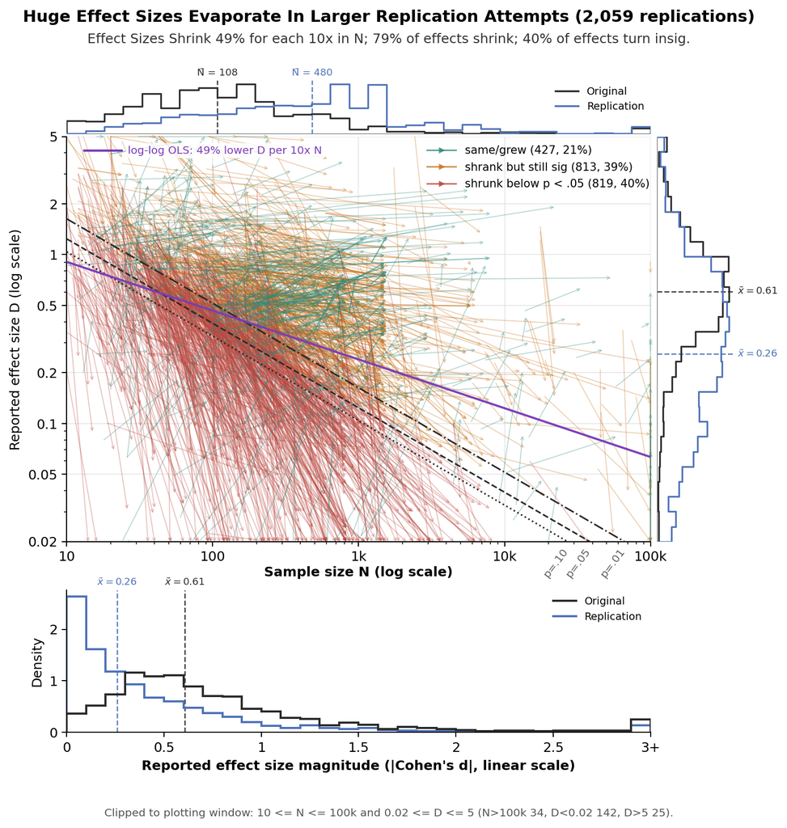

Current replication-pairs plot used in the main manuscript.

## Working Figure 1 Review

This temporary review block is generated from local TSV/PNG artifacts so the plotted routes can be checked in the HTML before any manuscript wording is hardened.

- Strict Figure 1A direct D/N rows: **2,059**.
- Additional binary clinical D-equivalent diagnostic rows: **88**.
- Native response/logit rows retained off the D axis: **88**.
- D/N rows currently blocked from Figure 1A by a rule gate: **669**.
- Local row universe shown in the subplot buckets: **3,324**.
- Full accounting denominator including parser-repair and duplicate-risk rows: **3,608**.

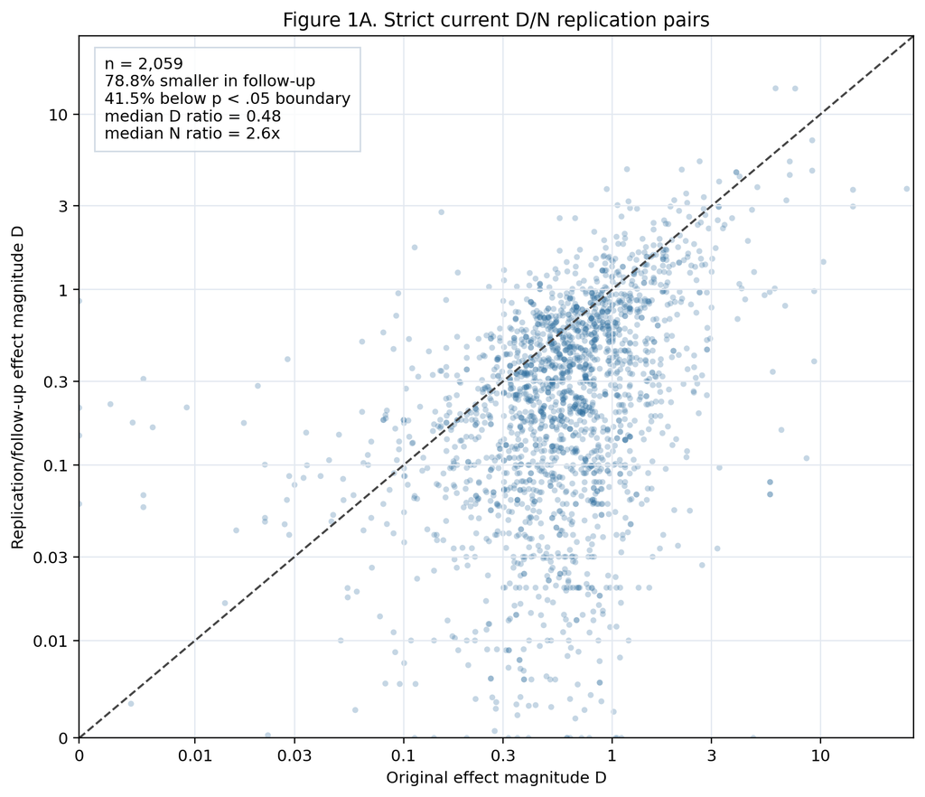

Working Figure 1A: strict direct-D panel. Axes use a symmetric log scale so zero-effect rows remain visible. The dashed line marks equality between original and follow-up effect magnitudes.

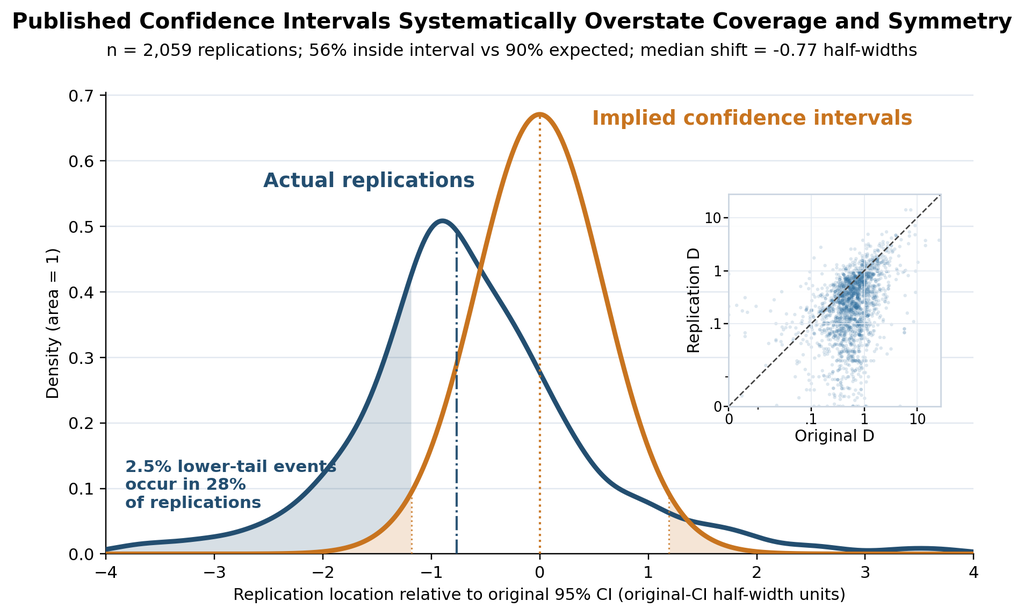

Standalone original-CI / replication compatibility density diagnostic. Replication point estimates are expressed in original-CI half-width units: -1 to +1 is the modeled original 95% interval and 0 is the original point estimate. The blue curve is the empirical observed density and the orange curve is the compatibility-implied predictive density from the modeled original and replication uncertainty; shaded orange regions mark the implied 2.5% tails, and blue shading marks observed excess density beyond the lower implied 95% cutoff. The inset shows the strict Figure 1A D/N scatter. These are not extracted source-reported confidence intervals.

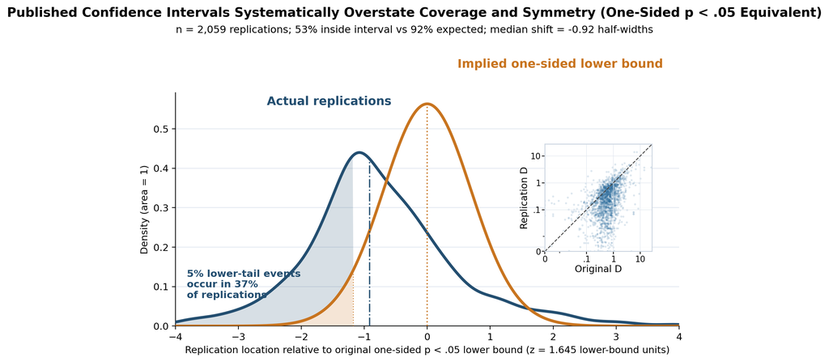

One-sided-test equivalent version of the same original-CI / replication compatibility diagnostic. This keeps the same rows and uncertainty model, but uses the z = 1.645 lower confidence bound corresponding to a one-sided p < .05 test. The upper side is open-ended; the shaded orange region marks only the implied 5% lower tail. These are not extracted source-reported confidence intervals.

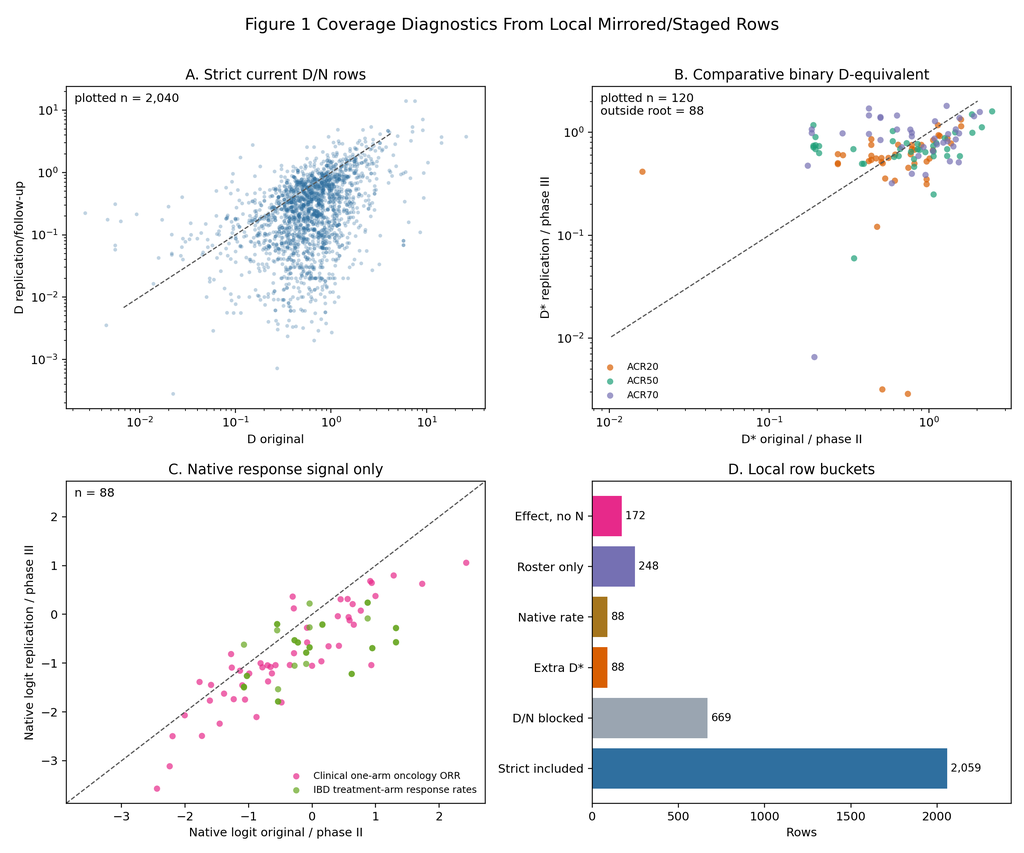

Additional Figure 1 route panels. Panel B keeps comparative binary endpoints on a D-equivalent axis; Panel C keeps response-rate rows on a native logit axis; Panel D shows local row buckets.

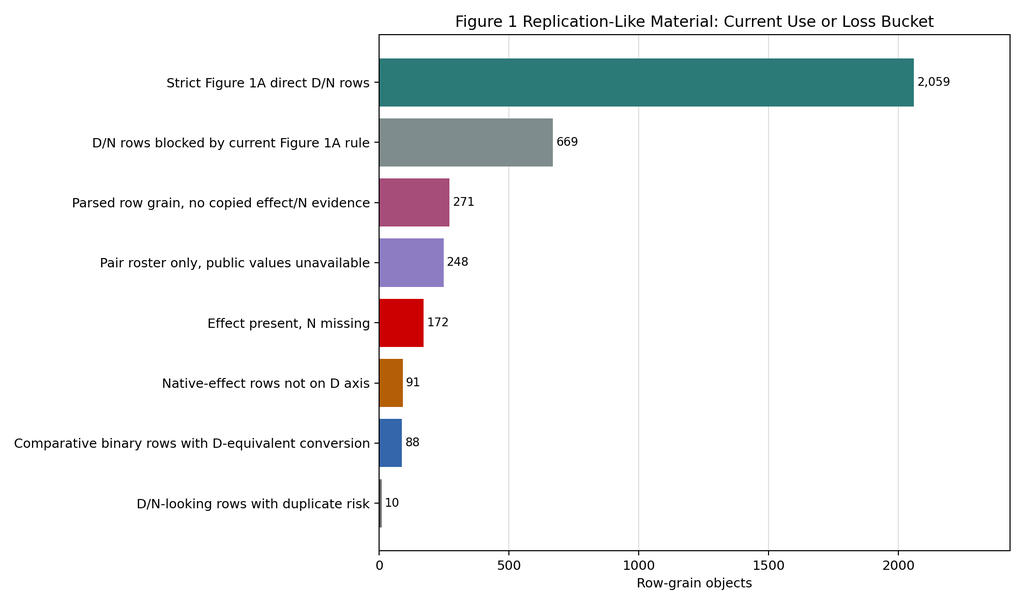

Coverage-loss accounting across strict Figure 1A, alternate diagnostic routes, repair queues, and denominator-only rows.

### Working Route Table

| disposition_label | row_count | usable_for | has_effect | has_n | has_common_axis |
| --- | --- | --- | --- | --- | --- |
| Strict Figure 1A direct D/N rows | 2059 | main Figure 1A | yes | yes | yes |
| D/N rows blocked by current Figure 1A rule | 669 | denominator, rule audit, robustness checks | yes | yes | yes, but not current-rule eligible |
| Comparative binary rows with D-equivalent conversion | 88 | Figure 1B diagnostic | yes | yes | D-equivalent tier, not direct D |
| Native-effect rows not on D axis | 91 | native-scale diagnostic, not common-D plot | yes | yes | no |
| Pair roster only, public values unavailable | 248 | coverage denominator only | no | no | no |
| Effect present, N missing | 172 | repair queue and denominator | yes | no | not until N is recovered |
| Parsed row grain, no copied effect/N evidence | 271 | denominator with parser caveat | no | no | no |
| D/N-looking rows with duplicate risk | 10 | coverage denominator until deduped | yes | yes | likely, but not validated |

## 2.2 Inclusion Criteria

Plot 1 keeps a row in the rendered Figure 2 subset when:

1. the row has an original side and a follow-up side with a common `D`/`Z`-convertible effect measure,
2. both sides have `N`,
3. both sides have `N >= 10`,
4. and the follow-up/replication `N` is larger than the original `N`.

Across the `2,553` live Plot 1 pair rows, `1,797` pass those gates, `0` are blocked by missing `D`/`Z`-convertible effects, `0` are blocked by missing `N`, `106` are blocked by `N < 10`, and `650` are blocked because replication `N <=` original `N`. The rendered figure has `1,803` rows because `6` Appendix D fallback rows are already plot-ready and are counted directly as kept.

Machine-readable gate matrix: plot1_replication_criteria_matrix.csv

Machine-readable source-table column criteria: plot1_replication_source_column_criteria.csv

### 2.2.1 Source-table column criteria

These definitions govern the `Corpora Considered` table below. They are intentionally explicit so source-audit language does not drift as new leads are checked.

| Column | Criterion |
| --- | --- |
| Source considered | Use the reader-facing canonical source family after alias normalization. Cite the family-level bibliographic key. Do not list every raw artifact here; artifact-level provenance belongs in the full aud… |
| What it is/Why Possible Candidate | State what the source is, then state why it was treated as a possible pair source. The rationale must say whether the source explicitly links original findings to replications/follow-ups, is a direct-… |
| Why in/out | Report the audit outcome under the current Plot 1 rules. Use explicit status language: confirmed usable; confirmed usable with exclusions; confirmed usable fallback; confirmed present but not usable; … |
| Kept for Figure | Count source-family rows that pass all Plot 1 row gates and appear in the rendered figure. Includes any approved catalog/backfill fallback rows. Zero means no row from that source family appears in th… |
| No D/Z | For live integrated pair rows, count rows failing first because either original or replication side lacks a common D/Z-convertible effect. This gate is evaluated before sample-size gates. Non-integrat… |
| No N | For live integrated pair rows that have D/Z on both sides, count rows failing because either original or replication N is missing. Rows already counted under No D/Z are not counted here. |
| N < 10 | For live integrated pair rows with D/Z and N on both sides, count rows failing because at least one side has N below 10. Rows already counted under No D/Z or No N are not counted here. |
| Rep N <= Orig N | For live integrated pair rows with D/Z, N on both sides, and both N values at least 10, count rows failing because the replication or follow-up N is not larger than the original N. This is the last ro… |

The source-by-source gate counts are folded into the combined `Corpora Considered` table below so the qualitative inclusion notes and quantitative rule outcomes stay on the same row.

## 2.3 Corpora Considered

Machine-readable display table: plot1_replication_source_display_table.csv

Full audit catalog: plot1_replication_source_catalog.csv; normalization worklist: plot1_replication_source_normalization_worklist.csv

Plot 1 currently includes `57` source families in the rendered Figure 2 rule subset, has `3` integrated live source families that contribute zero rows after the rule gate, tracks `1` support-only integrated sources, and leaves `26` checked families out of the rendered plot.

This table is normalized to source families for reading. The full audit catalog keeps lower-level artifacts, aliases, lead handles, and project slices so the roll-up is reversible.

[output not shown]

[output cut: 57 more lines]

## 2.4 Specific Observations Included

Machine-readable pair-level file: plot1_replication_pair_details.csv

The specific-observation layer has `1,803` Figure 2 rows. It records the source, smaller-`N` and larger-`N` paper labels/DOIs where available, endpoint, each side’s `D` and `N`, and `D_larger_N_minus_smaller_N`.

Preview of the first specific pair rows in source order:

| Source | Smaller-N paper | Larger-N paper | Outcome | Smaller-N D/N | Larger-N D/N | D diff |
| --- | --- | --- | --- | --- | --- | --- |
| 251 Rescue parsed data (Boyce et al. 2024) | Birch & Bloom 2007 | Birch & Bloom 2007 (additional) | t(149.58)=-1.20 | 0.47 / 103 | 0.19 / 152 | -0.27 |
| 251 Rescue parsed data (Boyce et al. 2024) | Birch & Bloom 2007 | Birch & Bloom 2007 (rescue) | t(237.01)=-1.4687 | 0.47 / 103 | 0.19 / 247 | -0.28 |
| 251 Rescue parsed data (Boyce et al. 2024) | Child et al. 2018 | Child et al. 2018 (rep1) | MSD2:m1=1860(1510),m2=1960(1490) | 0.11 / 35 | 0.07 / 40 | -0.05 |
| 251 Rescue parsed data (Boyce et al. 2024) | Child et al. 2018 | Child et al. 2018 (rescue) | MSD2:m1=1930(1400),m2=1930(1400) | 0.11 / 35 | 0.00 / 98 | -0.11 |
| 251 Rescue parsed data (Boyce et al. 2024) | Chou et al. 2016 | Chou et al. 2016 (rescue) | MSD2:m1=11.52066(18.72659),m2=10.39695(16.53978) | 0.42 / 100 | 0.06 / 252 | -0.35 |
| 251 Rescue parsed data (Boyce et al. 2024) | Craig & Richeson 2014 | Craig & Richeson 2014 (rescue) | MSD2:m1=-.4307766(3.529429),m2=.4463469(3.848955) | 0.50 / 121 | 0.24 / 127 | -0.26 |
| 251 Rescue parsed data (Boyce et al. 2024) | Haimovitz & Dweck 2016 | Haimovitz & Dweck 2016 (rescue) | t(129.45)=-0.31382 | 0.56 / 132 | 0.05 / 141 | -0.51 |
| 251 Rescue parsed data (Boyce et al. 2024) | Hopkins et al. 2016 | Hopkins et al. 2016 (rescue) | MSD2:m1=1.177984(.6890454),m2=1.355208(.7170742) | 0.35 / 147 | 0.25 / 161 | -0.10 |
| 251 Rescue parsed data (Boyce et al. 2024) | Jara-Ettinger et al. 2022 | Jara-Ettinger et al. 2022 (rep1) | rawprop:91/147,chance=1/3 | 9.12 / 144 | 7.10 / 147 | -2.02 |
| 251 Rescue parsed data (Boyce et al. 2024) | Jara-Ettinger et al. 2022 | Jara-Ettinger et al. 2022 (rescue) | rawprop:191/426,chance=1/3 | 9.12 / 144 | 4.77 / 426 | -4.36 |
| 251 Rescue parsed data (Boyce et al. 2024) | Ngo et al. 2019 | Ngo et al. 2019 (additional) | MSE1:m1=.07(.01),comp=0 | 1.28 / 31 | 1.26 / 32 | -0.02 |
| 251 Rescue parsed data (Boyce et al. 2024) | Ngo et al. 2019 | Ngo et al. 2019 (rescue) | MSE1:m1=.05(.06),comp=0 | 1.28 / 31 | 0.10 / 77 | -1.18 |

### 2.4.1 What Is Still Missing

- The remaining Plot 1 work is now substantive: access blocks, native-metric decisions, or missing machine-readable pair payloads.
- A few integrated families still retain artifact-level detail in the full audit catalog, but the reader-facing table is normalized to source families.
- Some support-only and cross-check sources still need a sharper distinction between `does not contribute rows` and `duplicate validation source`.

## 2.5 Current Files

The current replication-pair stack lives in a small set of derived files.

- Live integrated pair table: replication_pairs_all_on_hand.csv
- Figure 2 rule-qualified subset: replication_pairs_figure2_rule_subset.csv
- Source-level inclusion catalog: replication_pair_source_catalog.csv
- Lead-attempt manifest: harvest_manifest.csv
- Queue/status mirror: lead_queue_status.csv
- Human-readable mining log: overnight_mining_status.md
- Exhaustive evidence-surface inventory: replication_source_evidence_inventory.csv
- Consolidated source audit: replication_source_audit.csv
- Prioritized source worklist: replication_source_worklist.csv
- Human-readable audit summary: replication_source_audit.md
- Staged partial or blocked harvests: harvest/staged
- Promoted source-specific pair tables: harvest/promoted

## 2.6 Current Audit Snapshot

Every checked replication source should now be traceable through the canonical audit files listed below. In practice, `cataloged` means the source shows up in the non-lossy evidence inventory, the canonical source-family audit, the build-known source catalog, or the unresolved worklist as appropriate.

- Canonical source-family audit rows: `107` in replication_source_audit.csv
- Non-lossy evidence-surface rows: `346` in replication_source_evidence_inventory.csv
- Source datasets known to the current build: `105` in replication_pair_source_catalog.csv
- Prioritized unresolved checked sources: `10` in replication_source_worklist.csv
- Live integrated pair rows: `2,553` in replication_pairs_all_on_hand.csv
- Figure 2 rule-qualified rows: `1,803` in replication_pairs_figure2_rule_subset.csv
- Audit rows with integrated live data: `70`
- Audit rows with staged artifacts: `54`
- Audit rows with promoted artifacts: `26`
- Audit rows with raw directories present: `53`
- Audit rows flagged for manual backfill: `26`
- Legacy Appendix D target coverage: `527` / `555` rows, leaving a gap of `28`

### 2.6.1 Canonical audit status counts

| Audit status | Source families |
| --- | --- |
| integrated_live | 68 |
| staged_only | 24 |
| catalog_not_integrated | 12 |
| catalog_integrated | 2 |
| raw_artifact_only | 1 |

### 2.6.2 Legacy Appendix D family coverage

| Appendix family | Target rows | Covered rows | Remaining gap |
| --- | --- | --- | --- |
| Registered Replication Reports | 9 | 0 | 9 |
| Other direct replications | 3 | 0 | 3 |
| Many Labs 1 | 13 | 10 | 3 |
| Many Labs 2 | 28 | 28 | 0 |
| Many Labs 3 | 8 | 8 | 0 |
| Many Labs 4 | 1 | 0 | 1 |
| Many Labs 5 | 6 | 6 | 0 |
| SSRP | 20 | 20 | 0 |
| EERP | 18 | 18 | 0 |
| RPP / OSC 2015 | 98 | 98 | 0 |
| RP:CB | 24 | 24 | 0 |
| SCORE | 282 | 282 | 0 |
| Experimental philosophy / x-phi | 33 | 33 | 0 |
| Pipeline Project | 10 | 0 | 10 |
| DellaVigna-Linos 2022 | 1 | 0 | 1 |
| Marek 2022 BWAS | 1 | 0 | 1 |

### 2.6.3 Highest-priority unresolved checked sources

| Source | Recommended next step | Priority |
| --- | --- | --- |
| Marcus Four Lab Replication Hcmv7 | stage_downloaded_payload | 90 |
| Ying 2023 pilot-full-scale trials | complete_partial_manual_reconstruction | 85 |
| Border 2019 candidate gene replication | consider_native_metric_lane | 70 |
| EGAP Metaketa I | consider_native_metric_lane | 70 |
| ERN Pe RRR OpenNeuro | consider_native_metric_lane | 70 |
| Mullinix Leeper Druckman Freese 2015 | consider_native_metric_lane | 70 |
| Wood and Porter elusive backfire effect | consider_native_metric_lane | 70 |
| ManyBabies 3 | locate_machine_readable_payload | 55 |
| Self control neuroimaging replication | locate_machine_readable_payload | 55 |
| Media priming direct replication | resolve_access_block | 45 |

## 2.7 Unit of Analysis

The unit of analysis in the live replication corpus is **not** “one paper” and **not** “one raw effect row from every source.” It is a **paper-endpoint pair** after source-specific cleanup.

That means:

- one original paper can contribute more than one row if it makes more than one distinct claim or endpoint,
- one replication paper can contribute more than one row if it reports multiple distinct endpoints,
- obvious site-level repeats can be collapsed when they are clearly the same original paper × replication study × endpoint anchor,
- and sources that are naturally effect-level can still be harmonized to this cleaner endpoint-pair unit.

This choice avoids two different failure modes:

- **paper-level collapse** throws away real endpoint distinctions,
- **raw effect-row ingestion** creates fake multiplicity from lab splits, repeated labels, or within-paper redundancies.

## 2.8 Construction Workflow

### 2.8.1 Lead Discovery

Leads come from three broad routes:

- known replication projects and curated databases,
- manual mining of supplements, OSF/GitHub/Dataverse payloads, and public workbooks,
- source suggestions that require follow-up inspection.

Each lead is logged in the structured harvest files. The first-pass explanation of why a source did or did not make it usually begins in the lead manifest fields:

- `terminal_status`
- `access_class`
- `directness_class`
- `metric_class`
- `promotion_blocker`
- `next_action`
- `notes`

### 2.8.2 Staging

A source is staged when it is real, relevant, and worth preserving, but still not ready for the live corpus. Typical reasons include:

- the source is roster-only,
- the source has endpoint matches but no defensible common-metric effect yet,
- the source is native-metric only,
- the source is public but still needs parser work,
- the source overlaps an already integrated source and needs deduplication,
- or the source is promising but still blocked by partial access.

The staged directory is therefore a working archive, not a final dataset.

### 2.8.3 Promotion

A source is promoted when it yields rows that satisfy the current live-corpus schema:

- `original_title`
- `replication_title`
- `original_doi`
- `replication_doi`
- `outcome`
- `D_original`
- `N_original`
- `D_replication`
- `N_replication`

along with provenance fields such as `raw_file` and `match_author`.

Promotion is intentionally conservative. If the endpoint match is weak, the metric conversion is unstable, or the sample-size anchor is missing, the row stays staged rather than entering the live corpus.

### 2.8.4 Integration

The final integration step rebuilds the live pair tables and Figure 2 inputs from:

- built-in source handlers inside analyze_replication_pairs.py,
- plus every promoted CSV under harvest/promoted.

This separation matters. The integrated corpus is reproducible from code and promoted artifacts, not from ad hoc spreadsheet edits.

## 2.9 Inclusion and Metric Rules

### 2.9.1 Core Pair Logic

The live corpus prefers sources where the following are true:

- one earlier original study can be identified,
- one later larger new-sample study can be identified,
- the outcome or claim is the same or defensibly harmonized,
- the effect can be placed on a common axis,
- both sample sizes are known,
- and the later study is in fact larger.

### 2.9.2 Figure 2 Rule Subset

The stricter Figure 2 subset applies additional rules:

- both sides must have a usable common-metric effect size on the shared `D` axis,
- both sample sizes must be known and at least 10,
- the replication must be larger than the original,
- and obvious site-level repeats are collapsed to one endpoint-pair row when justified.

That is why many real checked sources exist in the audit trail but not in the plotted subset.

### 2.9.3 Why a Shared `D` Axis Was Used

The live cross-source corpus uses a shared `D`-like axis because it needs one common magnitude scale across literatures that report:

- standardized mean differences,
- correlations,
- odds ratios,
- hazard ratios,
- test statistics,
- and a variety of partially standardized summaries.

The point of the shared axis is narrow: compare the size of the original claim with the size of the larger follow-up claim on one common scale.

### 2.9.4 Why Percent Changes Were Not Used as the Common Axis

Percent changes and related “x% better” summaries are often denominator-sensitive. If the baseline is tiny, a trivial absolute change can look enormous in percent terms. That makes them too unstable for the main cross-study distribution.

For example, a move from `1%` to `2%` is a `100%` increase even though it is only a one-point absolute shift. That is exactly the wrong property for a dataset meant to compare magnitudes across very different domains.

### 2.9.5 The Problems of `D`

`D` is not neutral.

It can be inflated when:

- the pooled SD is unusually small,
- the sample is range-restricted,
- the subgroup is unusually homogeneous,
- the design is clustered or repeated-measures and the necessary structure is not fully recoverable,
- or the source metric has to be back-converted from ratios or adjusted models.

It also removes natural units and can hide baseline risk or direct clinical meaning. The project uses `D` because it is the least bad common axis for the replication-pairs plot, not because it is a perfect one.

### 2.9.6 Native-Metric Rows

Some sources are clearly real and clearly informative but should not yet be promoted to the live `D`-based replication corpus. This is especially common in:

- pilot/full-scale medical pairs,
- cluster-adjusted mean-difference studies,
- hazard-ratio survival endpoints,
- sources that only expose a defensible native metric.

Those rows belong in staging unless and until a separate native-metric lane is formalized.

## 2.10 Why Checked Sources Still Miss the Live Plot

The most common exclusion or blocking reasons currently fall into a few recurring classes.

### 2.10.1 Access Blocked

The source exists but the public payload is unavailable, restricted, empty, or not machine-retrievable in the current environment.

### 2.10.2 Parser Not Implemented

The source is public and probably usable, but no project-specific extractor has been written yet.

### 2.10.3 Endpoint Mismatch

The original and follow-up papers are about the same intervention family but not the same endpoint. These sources are often scientifically interesting and still valuable as staged records, but they do not belong in the strict agreement analyses.

### 2.10.4 Metric Blocked

The source has real pair information, but the effect metrics do not support a defensible shared-`D` conversion under the current policy.

### 2.10.5 Overlap or Duplicate Coverage

The source is real but duplicates or mirrors another already integrated source. In those cases it is useful as a cross-check, not as a new source of rows.

### 2.10.6 Roster-Only

The source identifies pairs but does not expose the per-pair analytic effect and sample-size table. This is now the status of the current Ying dissertation roster extraction.

## 2.11 Manual Recovery and the Ying Example

The current Ying 2023 work is a good example of why the audit layer matters.

The project now has:

- a verified `248`-pair bibliographic roster extracted from the dissertation,
- a staged partial reconstruction file,
- and one promoted pair that cleared the current `D`-based live-corpus rules.

That is not a failure of the source. It is an honest reflection of the difference between:

- “this source is real and worth preserving,”
- “this source gives us a pair roster,”
- “this source gives us native-metric evidence,”
- and “this source yields a fully promotable shared-`D` row right now.”

This distinction should become standard across the whole replication-pairs layer.

# 3 Plot 2 — Published Paper Endpoints

This is the paper-level `D`-vs-`N` cloud used to show what the published literature looks like before replication correction.

## 3.1 Figure

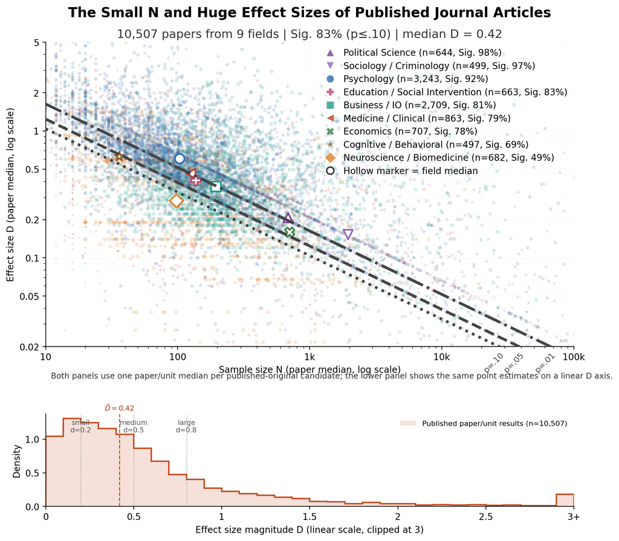

Current published-paper endpoint plot used in the main manuscript.

## 3.2 Inclusion Criteria

Plot 2 currently includes a source corpus when all of the following are true:

- the source yields **published-paper rows** rather than only replication-pair rows, registry rows, or pure meta-analytic summaries,
- a paper-level `D` and `N` can be recovered or aggregated,
- paper grouping is recoverable, so one plotted point can correspond to one published paper after source-specific cleanup,
- and the resulting paper-level cloud can be integrated without pretending that the project has already identified the one true headline result in every paper.

That last clause matters. Plot 2 is not yet a “main result only” figure. It is a paper-level published-result surface. So some sources are currently excluded not because they are uninteresting, but because they still fail one of the more basic gating conditions above.

Machine-readable matrix: plot2_published_criteria_matrix.csv

The counts below are strict current-layer counts, not best-case theoretical recoverability. If a source only has a `partial` flag for journal provenance or main-result identification, that criterion is counted as `0` here and left to the notes column rather than silently rounded up.

Under the current Plot 2 build, `10,507` paper points are plotted from `26` source corpora. Only `4,311` known paper units come from corpora that already carry an explicit or near-explicit main-result selector, which is why the current figure is still a paper-level published-result cloud rather than a clean main-result-only figure.

### 3.2.1 Source-table column criteria

These definitions govern the `Corpora Considered` table below. They are intentionally explicit so source-audit language does not drift as new Plot 2 leads are checked.

| Column | Criterion |
| --- | --- |
| Corpus considered | Name the source family evaluated for Plot 2. Use the canonical display label and citation when available. |
| What it is / why possible candidate | Describe the source type and why it looked like it could contribute published paper-level D/N point estimates. |
| Confirmed fields | Report the local evidence counts: known paper units, known test/effect rows, direct journal provenance, paper grouping, paper-level D/N, and main-result selector availability. |
| Why in/out | State the current Plot 2 decision. If included, name the remaining caveat; if excluded, name the blocking gate rather than just saying unavailable. |
| # obs in | Count plotted paper/unit rows entering the current Plot 2 cloud. Zero means the source is considered but contributes no plotted paper point right now. |

The source-by-source gate counts are folded into the combined `Corpora Considered` table below so the qualitative admission note and quantitative rule outcomes stay on the same row.

## 3.3 Corpora Considered

Machine-readable catalog: plot2_published_source_catalog.csv

Machine-readable gate matrix: plot2_published_criteria_matrix.csv

Plot 2 currently uses `26` source corpora in the rendered paper-level cloud and keeps `9` considered journal-result sources out of the current figure.

This is the corpus-level admission audit for Plot 2. It combines the qualitative source note with the current gate counts so the reader can see why each source was considered, what was actually confirmed, why it is in or out, and how many paper/unit rows enter the plotted cloud.

| Corpus considered | What it is / why possible candidate | Confirmed fields | Why in/out | # obs in |
| --- | --- | --- | --- | --- |
| DARPA SCORE / COS claims (Tyner et al. 2026) | Social and behavioral claims sampled for DARPA SCORE/COS. Possible Plot 2 candidate because the sampled journal claims expose enough N/effect/p text to reconstruct paper-level D/N, though many rows ar… | Known: 3,193 paper units, 3,684 test/effect rows. Confirmed: journal provenance: yes (3,193); paper grouping: yes (3,193); paper D/N: yes (3,193); main selector: no. | Included: parsed with caveats. Parser yields 2,893 free-text claim rows and 791 structured focal-test rows with D/N; representative/focal claims from journal papers, but not guaranteed declared headli… | 3,193 |
| metaBUS open Bosco subset (Bosco et al. 2019) | Open metaBUS subset for Journal of Applied Psychology and Personnel Psychology correlations. Possible candidate because the rows are peer-reviewed article effects with r and N; the caveat is that they… | Known: 1,999 paper units, 169,135 test/effect rows. Confirmed: journal provenance: yes (1,999); paper grouping: yes (1,999); paper D/N: yes (1,999); main selector: no. | Included: not treatment effects. Peer-reviewed JAP/Personnel Psychology correlation rows; useful D/N article corpus but not treatment/main-claim effects. | 1,999 |
| FORRT FReD (Tosh et al. 2025) | FORRT/FReD original findings selected for documented replications. Possible candidate because original-side titles, DOIs, N, and effects are available for many replication targets; the caveat is repli… | Known: 796 paper units, 1,969 test/effect rows. Confirmed: journal provenance: yes (796); paper grouping: yes (796); paper D/N: yes (796); main selector: yes (796). | Included: parsed with caveats. Parser yields 1,969 original-claim rows across 762 DOI units; rows are replication targets, usually focal claims, but not broad journal sampling and not always treatment… | 796 |
| Schäfer/Schwarz psychology articles (without preregistration) (Schäfer and Schwarz 2019) | Schäfer/Schwarz non-preregistered psychology-article sample. Possible candidate because each sampled paper has a coded key-question effect with recoverable D/N. | Known: 682 paper units, 682 test/effect rows. Confirmed: journal provenance: yes (682); paper grouping: yes (682); paper D/N: yes (682); main selector: yes (682). | Included: key-effect psychology sample. Random psychology-paper sample with coded key-question effects from non-preregistered articles; public rows include D/N but not DOI/title metadata. | 682 |
| Button/Nord neuroscience (Button et al. 2013) | Primary studies appearing in neuroscience meta-analyses. Possible candidate because D/N is recoverable at the published-study level; the caveat is meta-analysis mediation rather than direct paper-main… | Known: 649 paper units, 688 test/effect rows. Confirmed: journal provenance: no; paper grouping: yes (649); paper D/N: yes (649); main selector: no. | Included: meta-analysis-mediated. Published-study rows from meta-analyses; no direct journal-paper main-result flag. | 649 |
| Motyl social/personality critical tests (Motyl et al. 2017) | Motyl social/personality article sample with coded critical hypothesized tests. Possible candidate because the tests are close to focal claims, though some papers contribute multiple study-level tests… | Known: 540 paper units, 1,305 test/effect rows. Confirmed: journal provenance: yes (540); paper grouping: yes (540); paper D/N: yes (540); main selector: yes (540). | Included: critical hypothesized-test sample. Sampled social/personality journal articles with coded critical hypothesized tests; useful focal-result corpus but some papers contribute multiple study-le… | 540 |
| Kühberger psychology main results (Kühberger, Fritz, and Scherndl 2014) | Kühberger psychology main-result corpus. Possible candidate because it is a random psychology-article sample with one coded main-question result per paper and recoverable D/N. | Known: 472 paper units, 472 test/effect rows. Confirmed: journal provenance: yes (472); paper grouping: yes (472); paper D/N: yes (472); main selector: yes (472). | Included: clean psychology main-result sample. Random-sample psychology article corpus with one coded main-question result per paper and D/N recovered from the public SAV. | 472 |
| replication-pair original-side bridge (project}} 2026m) | Internal bridge from Plot 1 originals. Possible candidate because every plotted replication pair has an original-side D/N; the bridge adds only original DOI/title targets not already represented in Pl… | Known: 431 paper units, 635 test/effect rows. Confirmed: journal provenance: no; paper grouping: yes (431); paper D/N: yes (431); main selector: yes (431). | Included: derived bridge from Plot 1 originals. Checks every row already plotted in the replication-pair figure and adds original-side D/N estimates only when the original DOI/title is not already rep… | 431 |
| CliniFact published primary pairs (Zhang et al. 2025) | Published clinical-trial reports linked to registry primary outcomes through the local CliniFact bridge. Possible candidate because the rows are journal-side primary-outcome proxies with recoverable D… | Known: 339 paper units, 339 test/effect rows. Confirmed: journal provenance: yes (339); paper grouping: yes (339); paper D/N: yes (339); main selector: yes (339). | Included: registry-linked published primary-outcome proxy. Published trial reports linked to ClinicalTrials.gov primary outcomes through the local CliniFact bridge; conservative proxy for journal-side… | 339 |
| Olsson/Sundell social interventions (Olsson and Sundell 2023) | Published Swedish social-intervention effectiveness articles. Possible candidate because primary-outcome flags identify the plotted paper-level effectiveness results. | Known: 250 paper units, 250 test/effect rows. Confirmed: journal provenance: yes (250); paper grouping: yes (250); paper D/N: yes (250); main selector: yes (250). | Included: primary social-intervention outcomes. Published Swedish social-intervention effectiveness articles; primary-outcome flags are used for plotted rows and nonprimary rows remain comparator only… | 250 |
| Brodeur economics corpus (Brodeur, Cook, and Heyes 2020) | Published top-journal economics table tests from Brodeur-style p-value data. Possible candidate because RCT/IV/DID rows have N and test statistics, but no paper-main-result selector is available. | Known: 217 paper units, 10,071 test/effect rows. Confirmed: journal provenance: yes (217); paper grouping: yes (217); paper D/N: yes (217); main selector: no. | Included: causal-test corpus but not main-result selected. Rows are RCT/IV/DID table test statistics from published economics articles with N; no flag for the paper’s main result. | 217 |
| MetaLab (Bergmann et al. 2018) | MetaLab developmental-psychology database. Possible candidate because peer-reviewed flags and D/N exist, but rows are curated through a meta-analytic database rather than direct journal extraction. | Known: 202 paper units, 926 test/effect rows. Confirmed: journal provenance: no; paper grouping: yes (202); paper D/N: yes (202); main selector: no. | Included: curated meta-analysis database. Has D/N and peer_reviewed metadata, but effect rows are selected through meta-analytic databases rather than direct paper main-result extraction. | 188 |
| Esarey/Wu political science main findings (Esarey and Wu 2016) | Esarey/Wu political-science main-finding sample. Possible candidate because the source explicitly codes published article main findings and the local parser keeps the authors’ focal model restriction. | Known: 167 paper units, 167 test/effect rows. Confirmed: journal provenance: yes (167); paper grouping: yes (167); paper D/N: yes (167); main selector: yes (167). | Included: author-coded political-science main findings. Sampled political-science articles with author-coded main findings; parser keeps the authors’ model==1 and number_of_dv==1 restriction. | 167 |
| Linden focal effects (Linden, Pollet, and Hönekopp 2024) | Linden psychology focal-effect sample. Possible candidate because author-coded focal effects are recoverable with D/N, while non-focal random-effect rows remain comparator-only. | Known: 158 paper units, 158 test/effect rows. Confirmed: journal provenance: yes (158); paper grouping: yes (158); paper D/N: yes (158); main selector: yes (158). | Included: focal psychology sample. Random psychology-paper sample with author-coded focal effects; focal rows are plotted while random-effect rows are retained as comparator only. | 158 |
| Schäfer/Schwarz preregistered psychology articles (Schäfer and Schwarz 2019) | Schäfer/Schwarz preregistered psychology-article sample. Possible candidate because each sampled paper has coded key-question effects with D/N and preregistration status. | Known: 89 paper units, 89 test/effect rows. Confirmed: journal provenance: yes (89); paper grouping: yes (89); paper D/N: yes (89); main selector: yes (89). | Included: preregistered key-effect psychology sample. Preregistered psychology article sample from the same public corpus; key-question effects are D/N-ready and plotted separately from the non-prereg… | 89 |
| Yun RCT numerical extraction (Yun et al. 2024) | Numerical intervention-comparator-outcome rows extracted from PMC RCT full texts. Possible candidate because arm-level RCT statistics can yield D/N; the remaining caveat is missing primary-outcome sel… | Known: 85 paper units, 401 test/effect rows. Confirmed: journal provenance: yes (85); paper grouping: yes (85); paper D/N: yes (85); main selector: no. | Included: ICO rows need selector. Rows are intervention-comparator-outcome numerical RCT extractions from PMC full text; no primary-outcome flag, but Evidence Inference/SPIRIT metadata could support a… | 85 |
| Havránek gasoline-income meta-analysis (Havranek and Kokes 2015) | Published-source estimates from the Havránek gasoline-income meta-analysis. Possible candidate because observations and effect estimates are present, but the rows are meta-analysis mediated rather tha… | Known: 50 paper units, 286 test/effect rows. Confirmed: journal provenance: no; paper grouping: yes (50); paper D/N: yes (50); main selector: no. | Included: meta-analysis-mediated. Source estimates have publication flags and observation counts, but rows are curated through meta-analysis datasets rather than direct journal main-result extraction. | 50 |
| academic nudge journals (DellaVigna and Linos 2022) | Academic nudge RCT rows from DellaVigna/Linos. Possible candidate because journal-published treatment-arm effects have outcome and arm fields; the strongest available selector is most-significant arm,… | Known: 43 paper units, 106 test/effect rows. Confirmed: journal provenance: yes (43); paper grouping: yes (43); paper D/N: yes (43); main selector: no. | Included: treatment-arm selected but not primary-outcome flagged. Rows are intervention/treatment-arm effects with outcome and arm fields; mostsig can identify the most significant arm, not necessaril… | 43 |
| Havránek EIS (Havránek 2015) | Economics source estimates from the Havránek EIS/meta-analysis.cz series. Possible candidate because D/N can be reconstructed for published estimates, but rows are meta-analysis mediated and not paper… | Known: 169 paper units, 2,717 test/effect rows. Confirmed: journal provenance: no; paper grouping: yes (169); paper D/N: yes (169); main selector: no. | Included: meta-analysis-mediated. Rows are source estimates curated for meta-analyses; some publication flags exist, but not paper-main-result flags. | 33 |
| Havránek substitution meta-analysis (Havránek 2015) | Economics source estimates from a Havránek substitution meta-analysis. Possible candidate because publication flags and observation counts exist, but rows are meta-analysis mediated. | Known: 33 paper units, 566 test/effect rows. Confirmed: journal provenance: no; paper grouping: yes (33); paper D/N: yes (33); main selector: no. | Included: meta-analysis-mediated. Source estimates have publication flags and observation counts, but rows are curated through meta-analysis datasets rather than direct journal main-result extraction. | 33 |
| Havránek Armington meta-analysis (Bajzik et al. 2020) | Economics source estimates from the Havránek Armington meta-analysis. Possible candidate because publication flags and observation counts exist, but rows are meta-analysis mediated. | Known: 24 paper units, 1,383 test/effect rows. Confirmed: journal provenance: no; paper grouping: yes (24); paper D/N: yes (24); main selector: no. | Included: meta-analysis-mediated. Source estimates have publication flags and observation counts, but rows are curated through meta-analysis datasets rather than direct journal main-result extraction. | 24 |
| antidepressant journal rows (Turner et al. 2008) | Published antidepressant efficacy rows from Turner-style journal/regulatory comparisons. Possible candidate because journal-side trial efficacy effects are clean, small, and D/N-ready. | Known: 23 paper units, 35 test/effect rows. Confirmed: journal provenance: yes (23); paper grouping: yes (23); paper D/N: yes (23); main selector: yes (23). | Included: clean main efficacy calibration. Rows are trial antidepressant efficacy effects; journal rows can be compared to FDA/regulatory rows. | 23 |
| RPCB cancer biology original effects (Errington et al. 2021) | Original published preclinical cancer-biology effects selected for RPCB replication. Possible candidate because they are key original claims with D/N, but they are project-selected rather than broad j… | Known: 20 paper units, 135 test/effect rows. Confirmed: journal provenance: yes (20); paper grouping: yes (20); paper D/N: yes (20); main selector: yes (20). | Included: project-selected key effects. Original published-paper effects selected for replication; close to key-claim effects but small and replication-project selected rather than broad journal-sampl… | 20 |
| Havránek Frisch extensive-margin meta-analysis (Elminejad, Havranek, and Horvath 2021) | Economics source estimates from the Havránek Frisch extensive-margin meta-analysis. Possible candidate because publication flags and observation counts exist, but rows are meta-analysis mediated. | Known: 16 paper units, 367 test/effect rows. Confirmed: journal provenance: no; paper grouping: yes (16); paper D/N: yes (16); main selector: no. | Included: meta-analysis-mediated. Source estimates have publication flags and observation counts, but rows are curated through meta-analysis datasets rather than direct journal main-result extraction. | 16 |
| Gechert/Havránek sigma meta-analysis (Gechert et al. 2022) | Economics source estimates from the Gechert/Havránek sigma meta-analysis. Possible candidate because publication flags and observation counts exist, but rows are meta-analysis mediated. | Known: 6 paper units, 51 test/effect rows. Confirmed: journal provenance: no; paper grouping: yes (6); paper D/N: yes (6); main selector: no. | Included: meta-analysis-mediated. Source estimates have publication flags and observation counts, but rows are curated through meta-analysis datasets rather than direct journal main-result extraction. | 6 |
| Havránek Frisch intensive-margin meta-analysis (Elminejad, Havranek, and Horvath 2021) | Economics source estimates from the Havránek Frisch intensive-margin meta-analysis. Possible candidate because publication flags and observation counts exist, but rows are meta-analysis mediated. | Known: 4 paper units, 36 test/effect rows. Confirmed: journal provenance: no; paper grouping: yes (4); paper D/N: yes (4); main selector: no. | Included: meta-analysis-mediated. Source estimates have publication flags and observation counts, but rows are curated through meta-analysis datasets rather than direct journal main-result extraction. | 4 |
| AACT x PubMed primary outcomes (Du 2024) | AACT/PubMed registered-primary-outcome bridge. Possible candidate because registry primary outcomes can identify focal medical endpoints, but this is not yet a journal-extracted article-result table. | Known: source count not confirmed locally. Confirmed: journal provenance: no; paper grouping: no; paper D/N: no; main selector: no. | Not included: not started. Potential large medical proxy: primary registry outcome rows linked to PMIDs; not journal-extracted article results and registry-publication disagreements are expected. | 0 |
| Aczel negative-claim t-test comparator (project}} 2026a) | Aczel et al. null-hypothesis/negative-claim psychology audit. Possible candidate because the public table contains published article t tests with recoverable D/N; the caveat is that rows are selected … | Known: 30 paper units, 62 test/effect rows. Confirmed: journal provenance: yes (30); paper grouping: yes (30); paper D/N: yes (30); main selector: no. | Not included: comparator-only negative-claim audit. Public Aczel et al. null-hypothesis support audit yields 62 usable t-test D/N rows across 30 paper units after applying the authors’ strict analyzab… | 0 |
| ArelBundock political science via BEAR (Arel-Bundock et al. 2026) | Political-science estimates routed through BEAR/meta-analytic sources. Possible candidate because effects and Ns can exist, but source rows mix journals, reports, and working papers and lack direct ma… | Known: source count not confirmed locally. Confirmed: journal provenance: no; paper grouping: no; paper D/N: no; main selector: no. | Not included: meta-analysis-mediated. Rows come through peer-reviewed meta-analyses; underlying source rows may be journals, working papers, or reports and no main-result flag exists. | 0 |
| ClinicalTrials.gov registry-results comparator (Du 2024) | ClinicalTrials.gov registry-results extraction. Possible D/N comparator because registry primary-result rows expose N and p-value-derived effect proxies, but it is registry evidence rather than publis… | Known: 7,722 paper units, 108,196 test/effect rows. Confirmed: journal provenance: no; paper grouping: yes (7,722); paper D/N: yes (7,722); main selector: no. | Not included: registry-results comparator. The finer-grained ClinicalTrials.gov results extraction has primary registry-result D/N proxies for 7,722 trial/outcome units. It is not included because Plo… | 0 |
| GWAS Catalog (Yengo et al. 2022) | Curated published genome-wide-significant association hits. Possible candidate for a large D/N surface because sample sizes and effects exist, but it is not a sampled article-level treatment/result co… | Known: 6,711 paper units, 1,090,919 test/effect rows. Confirmed: journal provenance: no; paper grouping: yes (6,711); paper D/N: yes (6,711); main selector: no. | Not included: excluded comparator. Paper-linked curated genome-wide-significant association hits; not sampled article-level journal treatment/results rows. | 0 |
| Linden random-effect comparator rows (Linden, Pollet, and Hönekopp 2024) | Random-effect counterpart from the Linden psychology sample. Possible candidate because it has one random effect per sampled paper with D/N, but it is intentionally held out as a comparator to the foc… | Known: 158 paper units, 158 test/effect rows. Confirmed: journal provenance: yes (158); paper grouping: yes (158); paper D/N: yes (158); main selector: no. | Not included: random-effect comparator from an included source. The Linden random-effect rows cover the same 158 sampled psychology papers as the included focal-effect rows, but they are deliberately … | 0 |
| Olivier 2024 cardiovascular RCTs (Olivier et al. 2024) | Olivier cardiovascular RCT corpus. Possible candidate because the article reports 344 major cardiovascular RCTs with primary endpoints and 263 superiority effect-size rows; it stays out until a public… | Known: 344 paper units. Confirmed: journal provenance: yes (344); paper grouping: yes (344); paper D/N: 263/344; main selector: yes (344). | Not included: author-request target. 344 major cardiovascular RCTs with primary endpoints and 263 superiority effect-size rows reported by article; no public row-level CSV located. | 0 |
| Szucs and Ioannidis test-statistic corpus (Szucs and Ioannidis 2017) | Szucs/Ioannidis cognitive-neuroscience and psychology test-statistic corpus. Possible candidate because journal test statistics can be converted to D/N; it stays out until paper grouping and main-resu… | Known: 0 paper units, 26,796 test/effect rows. Confirmed: journal provenance: no; paper grouping: no; paper D/N: no; main selector: no. | Not included: row-level tests only for now. Published journal test-statistic corpus; no decoded paper grouping yet and no primary/main-result flag. | 0 |
| statcheck psychology corpus (Hartgerink 2016) | All extractable APA-style significance tests from psychology journal articles. Possible candidate because it is direct journal text with test statistics and N/df, but it lacks paper-main-result select… | Known: 13,889 paper units. Confirmed: journal provenance: yes (13,889); paper grouping: yes (13,889); paper D/N: yes (13,889); main selector: no. | Not included: not main-result selected. All extractable APA test statistics from journal articles; no primary/main/treatment-result flag. | 0 |

## 3.4 Specific Observations Included

Machine-readable paper-level file: plot2_published_paper_details.csv

The specific-observation layer has `10,507` plotted paper/unit rows. It records corpus citation, paper/unit id, paper reference text, field, journal/year where available, paper-level `D`, paper-level `N`, and the number of source tests used in the collapse.

Preview of the first specific paper rows in source order:

| Corpus | Paper/unit id | Paper/reference | Field | Journal/year | D/N | Tests used |
| --- | --- | --- | --- | --- | --- | --- |
| CliniFact published primary pairs (Zhang et al. 2025) | PMID:15327042 | Do cannabis-based medicinal extracts have general or specific effects on symptoms in multiple sclerosis? A dou | medicine_rct | 2004 | 0.52 / 160 | 1 |
| CliniFact published primary pairs (Zhang et al. 2025) | PMID:16186518 | Randomized, controlled trial of cannabis-based medicine in central pain in multiple sclerosis. | medicine_rct | 2005 | 0.71 / 63 | 1 |
| CliniFact published primary pairs (Zhang et al. 2025) | PMID:16772623 | Fluoxetine after weight restoration in anorexia nervosa: a randomized controlled trial. | medicine_rct | 2006 | 0.12 / 93 | 1 |
| CliniFact published primary pairs (Zhang et al. 2025) | PMID:17160407 | A comparison of twice-daily exenatide and biphasic insulin aspart in patients with type 2 diabetes who were su | medicine_rct | 2007 | 0.29 / 501 | 1 |
| CliniFact published primary pairs (Zhang et al. 2025) | PMID:17355549 | Randomized controlled trial of cannabis-based medicine in spasticity caused by multiple sclerosis. | medicine_rct | 2007 | 0.29 / 189 | 1 |
| CliniFact published primary pairs (Zhang et al. 2025) | PMID:17997224 | Sativex successfully treats neuropathic pain characterised by allodynia: a randomised, double-blind, placebo-c | medicine_rct | 2007 | 0.51 / 125 | 1 |
| CliniFact published primary pairs (Zhang et al. 2025) | PMID:18343253 | Topical amethocaine gel 4% for intramuscular injection in term neonates: a double-blind, placebo-controlled, r | medicine_rct | 2008 | 0.16 / 110 | 1 |
| CliniFact published primary pairs (Zhang et al. 2025) | PMID:18445842 | Double-blind randomized phase II study of the combination of sorafenib and dacarbazine in patients with advanc | medicine_rct | 2008 | 0.36 / 101 | 1 |
| CliniFact published primary pairs (Zhang et al. 2025) | PMID:18650514 | Sorafenib in advanced hepatocellular carcinoma. | medicine_rct | 2008 | 0.27 / 602 | 1 |
| CliniFact published primary pairs (Zhang et al. 2025) | PMID:18757088 | Ivabradine for patients with stable coronary artery disease and left-ventricular systolic dysfunction (BEAUTIF | medicine_rct | 2008 | 0.00 / 5,479 | 1 |
| CliniFact published primary pairs (Zhang et al. 2025) | PMID:18767928 | Comparison of the effect of denosumab and alendronate on BMD and biochemical markers of bone turnover in postm | medicine_rct | 2009 | 0.23 / 1,189 | 1 |
| CliniFact published primary pairs (Zhang et al. 2025) | PMID:18789766 | Comparison of subcutaneous interferon beta-1a with glatiramer acetate in patients with relapsing multiple scle | medicine_rct | 2008 | 0.03 / 718 | 1 |

### 3.4.1 What Is Still Missing

- The source-family admission table is now centralized, but several included sources still need more detailed source-specific collapse-rule prose.
- Some included corpora remain paper-level proxies without explicit main-result selectors; those caveats are recorded in the `Why in/out` column rather than hidden.
- The largest excluded candidates need either parser work, a public row-level payload, or a policy decision before they can move into the plotted paper-level cloud.

## 3.5 Current Files

The current published-endpoint stack now has a plot-specific source audit plus the row-level paper details used to draw the cloud:

- Candidate published-paper corpus: candidate_d_n_papers.csv
- Published field-group map: candidate_published_field_groups.csv
- Plot 2 source-corpus catalog: plot2_published_source_catalog.csv
- Plot 2 paper-level detail rows: plot2_published_paper_details.csv
- Plot 2 criterion matrix: plot2_published_criteria_matrix.csv
- Corpus bibliography inventory: corpus_papers.csv
- Corpus bibliography BibTeX: corpus_papers.bib

The older published_original_paper_d_vs_n.csv file is retained as a legacy summary from the earlier two-corpus draft path. It is no longer the feeder for the rendered Plot 2 figure or the Plot 2 source catalog.

## 3.6 What This Plot Currently Means

The current plot treats each published-original paper as one point, using a paper-level median `D` and median `N` after source-specific cleanup. It is therefore not a raw all-effects dump and not a pure one-paper-one-estimate registry. It is a harmonized paper-level endpoint cloud.

That design makes the plot interpretable, but it also means this layer needs its own audit standard. Section 3.3 is the current source-family admission audit: it records every considered corpus, why it was a plausible candidate, what fields were actually confirmed, why it is in or out, and how many paper/unit rows enter the cloud. The remaining gap is source-specific collapse-rule prose for several included corpora, not the existence of the audit table itself.

## 3.7 What Still Needs to Tighten

The source-family audit is now centralized in Section 3.3 and in plot2_published_source_catalog.csv. The remaining cleanup is more specific:

- one explicit statement of paper-level collapse rules by source family,
- follow-up decisions for the high-yield excluded candidates that need parser, access, or policy work,
- and one clearer distinction between the plot-ready paper-level cloud and any future all-source row dump.

# 4 Plot 3 — Preregistered Results

Plot 3 is the preregistered-results comparison layer, not a registry layer. Under the relaxed rule, “confirmatory” means the result is inside a plan written before the result was known. A paper no longer needs a single main-result selector if the local source identifies multiple preregistered hypothesis results; those planned results are collapsed to one median dot per paper/project before plotting when the source exposes a matched result set.

## 4.1 Figure

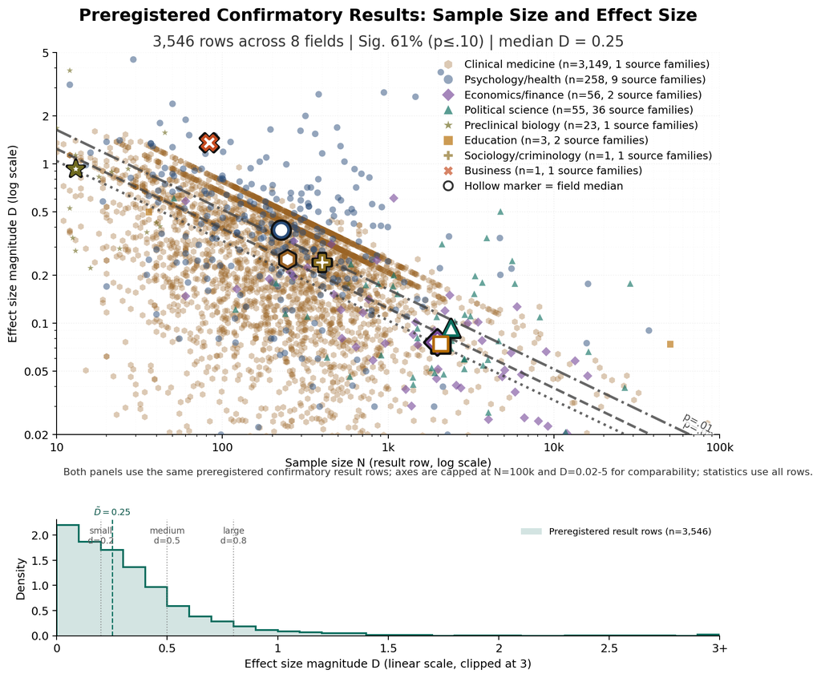

Preregistered confirmatory results on the same D/N scale used by the other plot layers.

## 4.2 Registry and Table-Test Comparators

Figure 3 is restricted to one dot per paper/project: either a single preregistered confirmatory result or a median of multiple matched planned-result rows. The underlying statistic must map to a precommitted hypothesis/result and have recoverable `D` and `N`. The comparator panels below deliberately show large local sources that are close enough to inspect but not comparable enough to enter Figure 3.

- **ClinicalTrials.gov registry-result comparator:** `7,722` trial-level registry-result rows from the local finer-grained CT.gov efficacy extraction. These are collapsed registry rows with `D/N` derived from registry p-values and enrollment-like `N`, not locked article-level confirmatory analyses.
- **Brodeur preregistered/PAP economics table tests:** `3,724` extracted economics table-test rows from papers flagged as preregistered, having a pre-analysis plan, or having PAP power information. The flags are paper/PAP-level evidence, while the plotted rows are individual published coefficients/tests.

They stay out of Figure 3 for opposite reasons. CT.gov fails the analytic-prespecification gate: a registered primary outcome is not the same as a locked statistical analysis plan, and the local effect is a p-value/enrollment proxy. Brodeur fails the row-unit gate: the data are many table tests per paper, with no source-provided focal hypothesis selector proving that each coefficient is the prespecified confirmatory test. The point of this panel is therefore diagnostic, not inferential: it shows what happens when we loosen the Figure 3 row definition to include preregistered-like registry and table-test evidence.

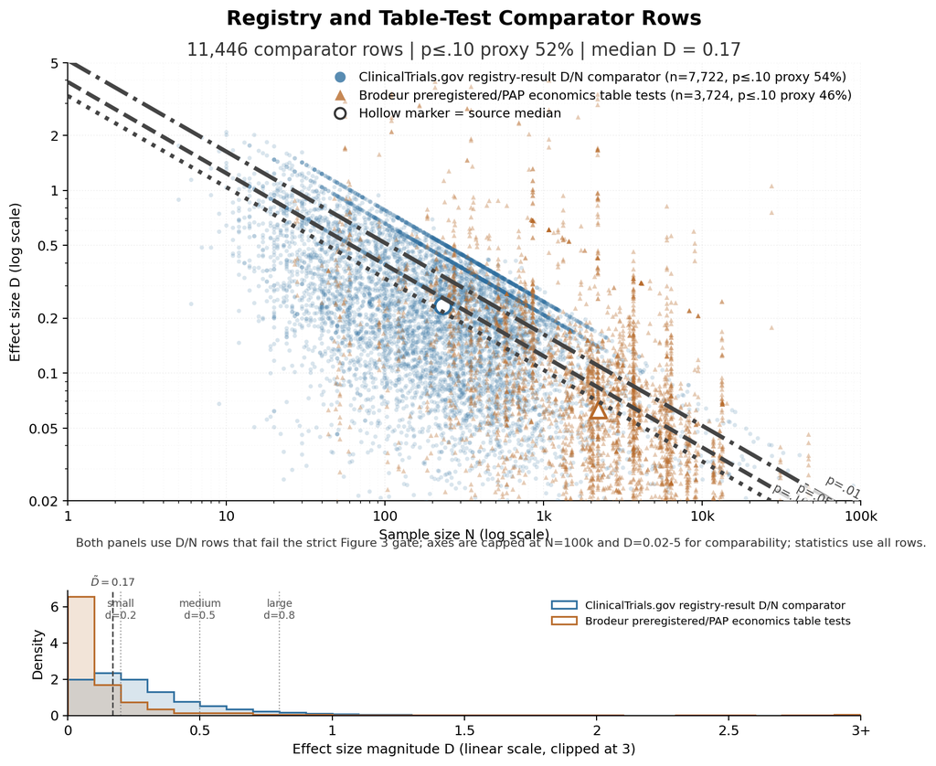

Registered and preregistered-like sidecar rows that have D/N locally but fail the strict Plot 3 confirmatory-result gate.

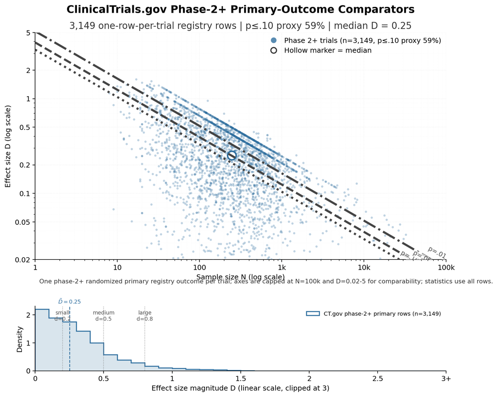

Cleaner ClinicalTrials.gov sub-sidecar: phase-2+ randomized trials with one locally eligible primary registry outcome per trial.

The larger ClinicalTrials.gov API pass below is the scale check. It uses the official API record, not the older KG proxy, and keeps registered primary, secondary, and other pre-specified outcome-analysis rows when a two-group denominator is present and `D` is recoverable from a ratio estimate, event-count/proportion row, or p-value proxy. The row-level file currently has `190,836` registered outcome-analysis rows from `17,726` randomized interventional trials; the figure plots one median per trial so the visual is not inflated by trials with hundreds of reported outcomes.

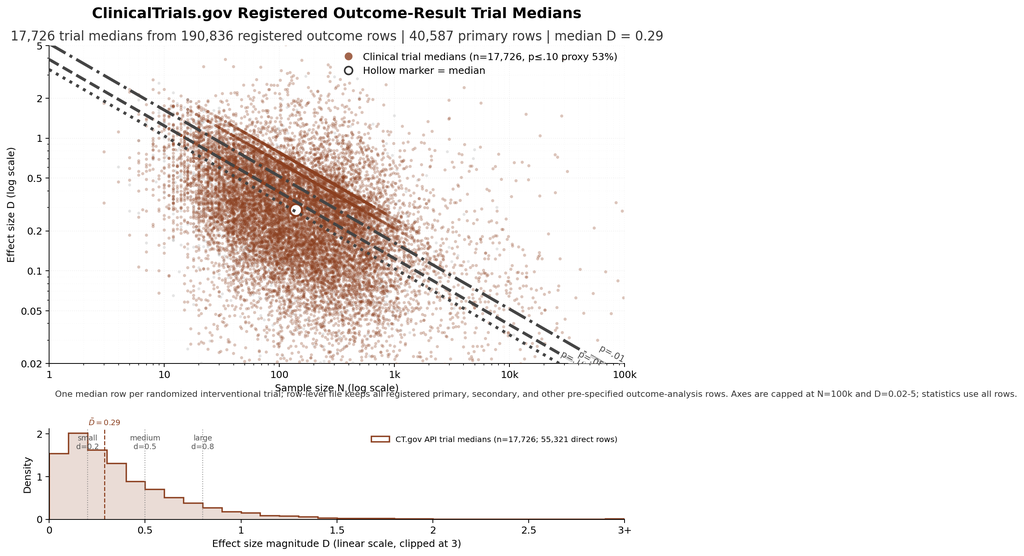

ClinicalTrials.gov API registered outcome-result trial medians, one median row per randomized interventional trial.

## 4.3 Inclusion Criteria

Plot 3 should include a source family when:

- the row family represents **planned preregistered results** rather than post hoc exploratory findings,
- `D` and `N` are recoverable or already encoded at the result level,
- the source is public and locally auditable,
- the plotted unit is one paper/project dot: either a preregistered hypothesis/result row or a median collapse of multiple matched planned-result rows from the same paper/project,
- and the source does not merely say “this paper was preregistered” while leaving the plotted statistic unlinked to the preregistered plan.

That is why mere clinical-trial registration is not enough for this layer. Registration can still be useful as a comparator, but it is not the same thing as an analytically preregistered confirmatory result.

Machine-readable matrix: plot3_preregistered_criteria_matrix.csv

These counts separate discovery from admission. `Extractable D/N rows` means the project has local numeric D/N rows somewhere for that source; `Currently included` means those rows also survive the analytic-preregistration, non-retraction, independence/deduplication, and current-layer policy gates. Under the relaxed rule, a source may expose multiple planned preregistered results per paper/project, but the plotted layer uses a median collapse when that within-paper result set is explicit.

Across the currently named Plot 3 source families, `201,009` / `222,209` considered rows already have local D/N encoding somewhere in the project, and `3,546` rows enter the preregistered-results plot after the gates are applied.

Source-table column criteria:

| Column | Criterion used |
| --- | --- |
| Corpus considered | One source family or deliberately tracked comparator family audited for Plot 3 admission. |
| What it is / why possible candidate | Brief source identity plus the concrete reason we thought it might contain preregistered confirmatory D/N rows. |
| Confirmed fields | Only fields verified locally or documented in the current audit: row counts, preregistration/registration status, D/N availability, support-status availability, and key caveats. |
| Why in/out | Final current gate call: included, excluded by analytic-preregistration, excluded by retraction, excluded as duplicate/nested evidence, or blocked by missing local row table. The focal-selector gate i… |
| # obs in | Number of result rows from that source family entering `plot3_preregistered_results.csv` and therefore the plotted figure. |

| Source family | Rows considered | Preregistered-confirmatory equivalent | Public local backing | Extractable D/N rows | Non-retracted source | Currently included |
| --- | --- | --- | --- | --- | --- | --- |
| CT.gov phase-2+ primary randomized rows (Du 2024) | 3,149 | 3,149 | 3,149 | 3,149 | 3,149 | 3,149 |
| van den Akker matched-result medians (Akker et al. 2023) | 193 | 193 | 193 | 126 | 193 | 125 |
| Schäfer/Schwarz preregistered psychology articles (Schäfer and Schwarz 2019) | 93 | 93 | 93 | 89 | 93 | 89 |
| Brodeur preregistered/PAP table tests (Brodeur, Cook, and Heyes 2020) | 10,071 | 10,071 | 10,071 | 3,724 | 10,071 | 70 |
| SCORE/COS preregistration-indicated papers (Tyner et al. 2026) | 245 | 245 | 245 | 34 | 245 | 34 |
| RPCB Registered Report replication effects (Errington et al. 2021) | 188 | 188 | 188 | 159 | 188 | 23 |
| Registered Reports preregistered-hypotheses corpus (Scheel, Schijen, and Lakens 2021) | 71 | 71 | 71 | 32 | 71 | 16 |
| PSA-CR002 cognitive reappraisal hypotheses (Wang et al. 2021) | 12 | 12 | 12 | 12 | 12 | 1 |
| PSA-CR001 pooled preregistered rows (Dorison et al. 2022) | 4 | 4 | 4 | 4 | 4 | 1 |
| Campaign-ad persuasion archive (Hewitt et al. 2024) | 1,008 | 1,008 | 1,008 | 1 | 1,008 | 1 |
| Kalla/Broockman campaign contact (Kalla and Broockman 2018) | 21 | 21 | 21 | 1 | 21 | 1 |
| Baraza public-service delivery preregistered community-monitoring field experiment (Mogues et al. 2020) | 20 | 20 | 20 | 1 | 20 | 1 |
| Bangladesh election information field experiment (Ahmed, Hodler, and Islam 2023) | 16 | 16 | 16 | 1 | 16 | 1 |
| COVID Emperor social-norm experiment (“Replication Materials for a Preregistered COVID-19 Social-Norm and Authoritative-Influence Survey Experiment” 2023) | 12 | 12 | 12 | 1 | 12 | 1 |
| Mousa 2020 Iraq soccer field experiment (“Replication Files for Building Social Cohesion Between Christians and Muslims Through Soccer in Post-ISIS Iraq” 2020) | 9 | 9 | 9 | 1 | 9 | 1 |
| Bangladesh school-WASH transparency preregistered field experiment (Allakulov et al. 2023) | 8 | 8 | 8 | 1 | 8 | 1 |
| Favero Pedersen COVID information-cue preregistered survey experiment (Favero and Pedersen 2020) | 8 | 8 | 8 | 1 | 8 | 1 |
| Immigration message-or-messenger preregistered survey experiment (Afrouzi, Arteaga, and Weisburst 2024) | 8 | 8 | 8 | 1 | 8 | 1 |
| Public-service job-attributes experiment (Favero, Pedersen, and Park 2022) | 8 | 8 | 8 | 1 | 8 | 1 |
| Senegal accountability field experiment (Gottlieb 2019) | 8 | 8 | 8 | 1 | 8 | 1 |
| India anti-vote-buying radio-campaign preregistered field experiment (Schechter and Vasudevan 2023) | 6 | 6 | 6 | 1 | 6 | 1 |
| Policing in patriarchy field experiment (Sukhtankar, Kruks-Wisner, and Mangla 2022) | 6 | 6 | 6 | 1 | 6 | 1 |
| Vietnam legislator responsiveness (Malesky et al. 2021) | 6 | 6 | 6 | 1 | 6 | 1 |
| Golden/Gulzar/Sonnet responsiveness (Golden, Gulzar, and Sonnet 2025) | 5 | 5 | 5 | 1 | 5 | 1 |
| Political activists free-riding experiment (Hager et al. 2023) | 5 | 5 | 5 | 1 | 5 | 1 |
| Good Politicians field experiment (Gulzar and Khan 2024) | 4 | 4 | 4 | 1 | 4 | 1 |
| TESS Johnson 1389 survey experiment (“TESS Study Johnson1389” 2024) | 4 | 4 | 4 | 1 | 4 | 1 |
| Ukrainian-refugee destination-choice preregistered conjoint experiment (Adema et al. 2025) | 4 | 4 | 4 | 1 | 4 | 1 |
| Direct-aid humanitarian-governance preregistered field experiment (Callen et al. 2025) | 3 | 3 | 3 | 1 | 3 | 1 |
| Political activists field experiment (Hensel and Rink 2023) | 3 | 3 | 3 | 1 | 3 | 1 |
| China-aid attitudes survey experiment (Terence Wood, Hoy, and Pryke 2023) | 3 | 3 | 3 | 1 | 3 | 1 |
| COVID vaccine-hesitancy message experiment (Reddinger, Levine, and Charness 2025) | 2 | 2 | 2 | 1 | 2 | 1 |
| Ghana debates field experiment (Ofosu, Brierley, and Kramon 2020) | 2 | 2 | 2 | 1 | 2 | 1 |
| Kotsadam Keller Elwert interethnic-contact preregistered field experiment (Kotsadam, Keller, and Elwert 2023) | 2 | 2 | 2 | 1 | 2 | 1 |
| Medicine-theft remote-tracking preregistered governance field experiment (Seim et al. 2023) | 2 | 2 | 2 | 1 | 2 | 1 |
| Vietnam National Assembly responsiveness (Todd et al. 2020) | 2 | 2 | 2 | 1 | 2 | 1 |
| JEPS political-knowledge replication (Azevedo, Bolesta, and Micheli 2022) | 1 | 1 | 1 | 1 | 1 | 1 |
| EGAP Metaketa I pooled PAP row (“EGAP Metaketa i Replication Repository” 2019) | 1 | 1 | 1 | 1 | 1 | 1 |
| EGAP Metaketa III pooled PAP row (“EGAP Metaketa III OSF Project” 2021) | 1 | 1 | 1 | 1 | 1 | 1 |
| EGAP Metaketa IV pooled PAP row (“EGAP Metaketa IV OSF Project” 2021) | 1 | 1 | 1 | 1 | 1 | 1 |
| Liberia Partnership Schools (Romero, Sandefur, and Sandholtz 2020) | 1 | 1 | 1 | 1 | 1 | 1 |
| Local Elites tax compliance (Balan et al. 2025) | 1 | 1 | 1 | 1 | 1 | 1 |
| ManyBabies 1 bilingual IDS pooled row (Byers-Heinlein et al. 2021) | 1 | 1 | 1 | 1 | 1 | 1 |
| ManyBabies 1 IDS pooled row (ManyBabies Consortium 2020) | 1 | 1 | 1 | 1 | 1 | 1 |
| ManyClasses 1 feedback pooled row (Fyfe et al. 2021) | 1 | 1 | 1 | 1 | 1 | 1 |
| PSA004 true-belief/Gettier pooled row (Hall et al. 2024) | 1 | 1 | 1 | 1 | 1 | 1 |
| TESS Graham 1155 survey experiment (“TESS Study Graham1155” 2024) | 1 | 1 | 1 | 1 | 1 | 1 |
| ClinicalTrials.gov API registered outcome-result universe (Du 2024) | 190,836 | 17,726 | 190,836 | 190,836 | 190,836 | 0 |
| FORRT FReD / Replication Database (Tosh et al. 2025) | 877 | 0 | 877 | 877 | 877 | 0 |
| Schäfer/Schwarz non-preregistered comparator (Schäfer and Schwarz 2019) | 900 | 0 | 900 | 682 | 900 | 0 |
| FReD archived workflow rescue queue (Tosh et al. 2025) | 343 | 0 | 343 | 343 | 343 | 0 |
| CliniFact published trial primary-outcome rows (Zhang et al. 2025) | 339 | 0 | 339 | 339 | 339 | 0 |
| Linden focal/random psychology sample (Linden, Pollet, and Hönekopp 2024) | 316 | 0 | 316 | 316 | 316 | 0 |
| PSA replication-pair rows (project}} 2026j) | 93 | 93 | 93 | 93 | 93 | 0 |
| Many Labs 1-5 project-level replication rows (project}} 2026f) | 69 | 69 | 69 | 69 | 69 | 0 |
| Registered Replication Reports Plot 1 pair rows (project}} 2026l) | 49 | 49 | 49 | 49 | 49 | 0 |
| Communication privacy preregistered corpus (Masur and Ranzini 2025) | 31 | 31 | 31 | 31 | 31 | 0 |
| High-Replicability Research project (Protzko et al. 2024) | 48 | 48 | 3 | 3 | 0 | 0 |
| Retrieval-extinction rats preregistered replication (Luyten and Beckers 2017) | 3 | 3 | 3 | 3 | 3 | 0 |
| Transparent Psi Project / Bem row (Kekecs et al. 2023) | 1 | 1 | 1 | 1 | 1 | 0 |
| Nordic trial registration-publication linkage (project}} 2026h) | 7,461 | 0 | 7,461 | 0 | 7,461 | 0 |
| AACT x PubMed registered primary outcomes (Du 2024) | 2,720 | 0 | 0 | 0 | 2,720 | 0 |
| COMPare prespecified outcome audit (project}} 2026c) | 1,171 | 749 | 1,171 | 0 | 1,171 | 0 |
| TESS survey-experiment archive (“TESS Past Studies Archive” 2026) | 517 | 517 | 517 | 0 | 517 | 0 |
| van den Akker selective-hypothesis-reporting corpus (Akker et al. 2023) | 459 | 459 | 446 | 0 | 459 | 0 |
| Twomey kinesiology article audit (project}} 2026n) | 300 | 27 | 300 | 0 | 300 | 0 |
| Registered Replication Reports per-lab rows (project}} 2026k) | 205 | 205 | 0 | 0 | 205 | 0 |
| Allen/Mehler RR support-rate review (Allen and Mehler 2019) | 113 | 113 | 113 | 0 | 113 | 0 |
| EGAP Metaketa IV native rows (“EGAP Metaketa IV OSF Project” 2021) | 36 | 36 | 36 | 0 | 36 | 0 |
| EGAP Metaketa III native rows (“EGAP Metaketa III OSF Project” 2021) | 30 | 30 | 30 | 0 | 30 | 0 |
| ManyClasses 2 classroom materials (“ManyClasses 2 OSF Project” n.d.) | 30 | 30 | 30 | 0 | 30 | 0 |
| ManyBabies 3 registered-report materials (“ManyBabies 3 OSF Project” n.d.) | 15 | 15 | 0 | 0 | 15 | 0 |
| Political-science rescue worklist (project}} 2026i) | 14 | 14 | 14 | 0 | 14 | 0 |
| ManyBabies 2 native model-coefficient materials (“ManyBabies 2 Analysis Repository” n.d.) | 4 | 4 | 4 | 0 | 4 | 0 |
| Self-control fMRI preregistered materials (“Self Control Neuroimaging Replication OSF Project” 2022) | 4 | 4 | 0 | 0 | 4 | 0 |
| EGAP Metaketa I native ATE rows (“EGAP Metaketa i Replication Repository” 2019) | 1 | 1 | 1 | 0 | 1 | 0 |
| ERN/Pe RRR OpenNeuro/OSF hubs (“ERN Pe Psychometrics Registered Replication Report OpenNeuro Dataset” 2023) | 1 | 1 | 0 | 0 | 1 | 0 |
| ManyBabies 4 helpers/hinderers RR materials (“ManyBabies 4 Helpers/Hinderers Project” n.d.) | 1 | 1 | 1 | 0 | 1 | 0 |

For Plot 3, the real bottleneck is not discovery. It is converting conceptually relevant preregistered-like sources into local auditable source tables that survive the non-retraction and analytic-preregistration gates.

## 4.4 Corpora Considered

Machine-readable catalog: plot3_preregistered_source_catalog.csv

At the moment Plot 3 has `47` included source families and `31` explicitly considered but not included source families.

This table is the corpus-level admission audit: what was considered, why it looked eligible, what fields were actually confirmed, why it is in or out, and how many observations made it into the plotted layer.